# Davidson & MacKinnon. Econometric Theory and Methods. (1999)

## Exercise 5.20.

### Construct two .95 bootstrap confidence intervals for the log of the mean income (not the mean of the log of income) of group 3 individuals from the earnings.data. These intervals should be based on (5.54) and (5.55). Verify that these two intervals are different.

We will load "earnings.data.txt" (provided by the authors in http://qed.econ.queensu.ca/ETM/data/), and filter the database to have only the earnings from the observations with individuals from group 3, that is, observations with the "dummy_group_3" columns equal to 1. The density plot of the group 3 individuals' earnings, as we can observe below, is asymmetric.

```r
data = read.table("earnings.data.txt",col.names=c("n","dummy_group_1","dummy_group_2","dummy_group_3", "earnings"))
    # Column 1 is the observation number.
    # Column 2 is a dummy variable for individuals in group 1.
    # Column 3 is a dummy variable for individuals in group 2.
    # Column 4 is a dummy variable for individuals in group 3.

    # These data were derived from those used by
    # Jeffrey A. Mills and Sourushe Zandvakili, "Statistical Inference via
    #   Bootstrapping for Measures of Inequality," Journal of Applied
    # Econometrics, Vol. 12, No. 2, 1997, pp. 133-150.

    # They are average annual earnings in 1988 and 1989, in 1982 US dollars,
    # for individuals in three age groups. See the paper for details.

#Filtering only observations from the group 3
data_group_3 = data[data$dummy_group_3 == 1,] ; head(data_group_3) ; tail(data_group_3)
```

| n | dummy_group_1 | dummy_group_2 | dummy_group_3 | earnings |
| --- | --- | --- | --- | --- |
| 1 | 0 | 0 | 1 | 569.5 |
| 2 | 0 | 0 | 1 | 895.5 |
| 3 | 0 | 0 | 1 | 1111.0 |
| 4 | 0 | 0 | 1 | 1182.0 |
| 5 | 0 | 0 | 1 | 1277.5 |
| 6 | 0 | 0 | 1 | 1384.0 |

|  | n | dummy_group_1 | dummy_group_2 | dummy_group_3 | earnings |
| --- | --- | --- | --- | --- | --- |
| 1474 | 1474 | 0 | 0 | 1 | 83810.5 |
| 1475 | 1475 | 0 | 0 | 1 | 83810.5 |
| 1476 | 1476 | 0 | 0 | 1 | 83810.5 |
| 1477 | 1477 | 0 | 0 | 1 | 83810.5 |
| 1478 | 1478 | 0 | 0 | 1 | 83810.5 |
| 1479 | 1479 | 0 | 0 | 1 | 83810.5 |

We get the number of observations and the mean of earnings and, then, we calculate the standard error $s_\beta$ with earnings mean ${\hat \beta}$ given by $$ s_{\beta} = \frac{\sigma_\beta}{\sqrt{n}} $$ and also generate the rescaled residuals $u^*_t$ defined by $$ u^*_t = \bigg(\frac{n}{n-1}\bigg)^{1/2} (y_t - {\hat \beta}) $$ that will be used to generate the bootstrap samples from the EDF.

```
[1] "n = 1479"
[1] "sigma = 1479"
[1] "mean of earnings = 27973.6345503719"
```

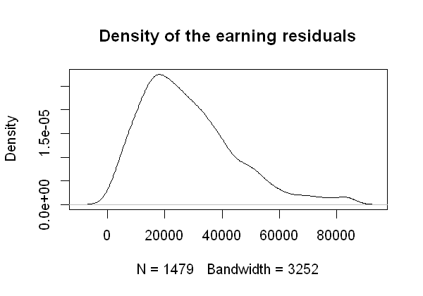

```r
#Getting the estimates
n = length(data_group_3[,1]); print(paste0("n = ", n))
std_error = sd(data_group_3$earnings)/sqrt(n) ; print(paste0("sigma = ", n))
mean_earnings = mean(data_group_3$earnings) ; print(paste0("mean of earnings = ", mean_earnings))
resid = ((n /(n - 1))^(1/2)) * (data_group_3$earnings - mean_earnings)

#Plotting the density of the residuals of the earnings from individuals from group 3
options(repr.plot.width=5, repr.plot.height=3.5)
plot(density(data_group_3$earnings), main = "Density of the earning residuals")
```

Now, we will perform the first semiparametric bootstrap, that is, we sample the residuals from the EDF, generate the bootstraped earnings and calculate the mean of earnings and the standard error in each one of B = 10000 samples.

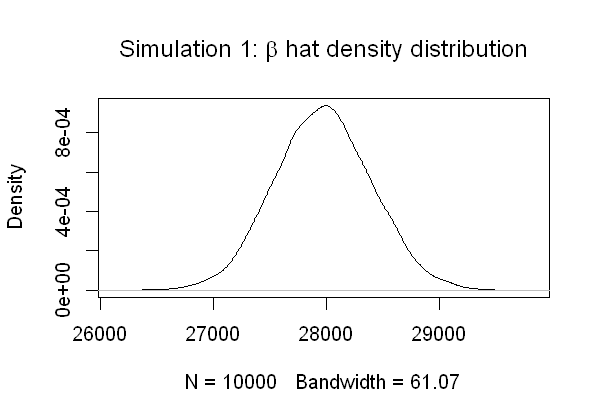

```r
#First Simulation
B = 10000

estimates_boot_1 = data.frame("beta_hat"=as.double(), "std_error_hat"=as.double())

#Semiparametric Bootstrap
for(i in 1:B){
    resid_boot = sample(resid, size = n, replace = TRUE)
    earnings_boot = mean(data_group_3$earnings) + resid_boot
    estimates_boot_1[i,"beta_hat"] = mean(earnings_boot)
    estimates_boot_1[i,"std_error_hat"] = sd(earnings_boot)/sqrt(n)
}

options(repr.plot.width=5, repr.plot.height=3.5)
plot(density(estimates_boot_1$beta_hat), main = expression("Simulation 1:"~beta~"hat density distribution"))
```

Then, we calculate the .95 bootstrap confidence intervals for earnings and log(earnings), by using the means and the standard deviations and, for comparison, by using the quantiles (asymptotic bootstrap).

```r
#Earnings interval
cat("earnings interval:\n")
print(paste0("The bootstrap earnings interval:[",
             round(mean(estimates_boot_1$beta_hat)+qnorm(0.025)*mean(estimates_boot_1$std_error_hat), 0), ", ",
             round(mean(estimates_boot_1$beta_hat)+qnorm(0.975)*mean(estimates_boot_1$std_error_hat), 0), "]"))

print(paste0("The asymptotic bootstrap earnings interval: [",
             round(mean(quantile(estimates_boot_1$beta_hat, 0.025), 0)), ", ",
             round(mean(quantile(estimates_boot_1$beta_hat, 0.975), 0)), "]"))


#log(Earnings) interval
cat("\nlog(earnings) interval:\n")
print(paste0("The bootstrap log(earnings) interval: [",
             round(log(mean(estimates_boot_1$beta_hat)+qnorm(0.025)*mean(estimates_boot_1$std_error_hat)), 4), ", ",
             round(log(mean(estimates_boot_1$beta_hat)+qnorm(0.975)*mean(estimates_boot_1$std_error_hat)), 4), "]"))

print(paste0("The asymptotic bootstrap log(earnings) interval: [",
             round(mean(quantile(log(estimates_boot_1$beta_hat), 0.025)), 4), ", ",
             round(mean(quantile(log(estimates_boot_1$beta_hat), 0.975)), 4), "]"))
```

```
earnings interval:
[1] "The bootstrap earnings interval:[27127, 28809]"
[1] "The asymptotic bootstrap earnings interval: [27143, 28810]"

log(earnings) interval:
[1] "The bootstrap log(earnings) interval: [10.2083, 10.2685]"
[1] "The asymptotic bootstrap log(earnings) interval: [10.2089, 10.2685]"
```

For the second simulation, given the standard error $\sigma_\beta$ of the mean income $\hat \beta$, we wi'll compute in each sampling the the logarithm of mean income and the delta method standard error, which is defined by $$ log{(\hat \beta)} =\frac{s_{\beta}}{{\hat \beta}}$$

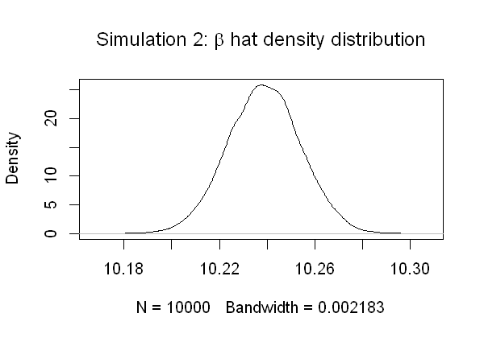

```r
#Second Simulation - With Delta Method Standard Error
estimates_boot_2 = data.frame("beta_hat"=as.double(), "std_error_hat"=as.double())

#Semiparametric Bootstrap
for(i in 1:B){
    resid_boot = sample(resid, size = n, replace = TRUE)
    earnings_boot = mean(data_group_3$earnings) + resid_boot
    estimates_boot_2[i,"beta_hat"] = log(mean(earnings_boot))
    estimates_boot_2[i,"std_error_hat"] = (sd(earnings_boot)/sqrt(n))/mean(earnings_boot)
}

options(repr.plot.width=5, repr.plot.height=3.5)
plot(density(estimates_boot_2$beta_hat), main = expression("Simulation 2:"~beta~"hat density distribution"))
```

Analogously with Simulation 1, we calculate the .95 bootstrap confidence intervals for log(earnings), by using the means and the standard deviations and, for comparison, by using the quantiles (asymptotic bootstrap).

```r
#log(Earnings) interval
cat("\nlog(earnings) interval:\n")
print(paste0("The bootstrap log(earnings) interval: [",
             round(mean(estimates_boot_2$beta_hat)+qnorm(0.025)*mean(estimates_boot_2$std_error_hat), 4), ", ",
             round(mean(estimates_boot_2$beta_hat)+qnorm(0.975)*mean(estimates_boot_2$std_error_hat), 4), "]"))


print(paste0("The asymptotic bootstrap log(earnings) interval: [",
             round(mean(quantile(estimates_boot_2$beta_hat, 0.025)), 4), ", ",
             round(mean(quantile(estimates_boot_2$beta_hat, 0.975)), 4), "]"))
```

```
log(earnings) interval:
[1] "The bootstrap log(earnings) interval: [10.2088, 10.2689]"
[1] "The asymptotic bootstrap log(earnings) interval: [10.2086, 10.2689]"
```

The both Simulations 1 and 2 intervals only differs slightly, the differences are only on the third/fourth decimal places.